# Starbucks Capstone Challenge

### Introduction

This data set contains simulated data that mimics customer behavior on the Starbucks rewards mobile app. Once every few days, Starbucks sends out an offer to users of the mobile app. An offer can be merely an advertisement for a drink or an actual offer such as a discount or BOGO (buy one get one free). Some users might not receive any offer during certain weeks.

Not all users receive the same offer, and that is the challenge to solve with this data set.

Your task is to combine transaction, demographic and offer data to determine which demographic groups respond best to which offer type. This data set is a simplified version of the real Starbucks app because the underlying simulator only has one product whereas Starbucks actually sells dozens of products.

Every offer has a validity period before the offer expires. As an example, a BOGO offer might be valid for only 5 days. You'll see in the data set that informational offers have a validity period even though these ads are merely providing information about a product; for example, if an informational offer has 7 days of validity, you can assume the customer is feeling the influence of the offer for 7 days after receiving the advertisement.

You'll be given transactional data showing user purchases made on the app including the timestamp of purchase and the amount of money spent on a purchase. This transactional data also has a record for each offer that a user receives as well as a record for when a user actually views the offer. There are also records for when a user completes an offer.

Keep in mind as well that someone using the app might make a purchase through the app without having received an offer or seen an offer.

### Example

To give an example, a user could receive a discount offer buy 10 dollars get 2 off on Monday. The offer is valid for 10 days from receipt. If the customer accumulates at least 10 dollars in purchases during the validity period, the customer completes the offer.

However, there are a few things to watch out for in this data set. Customers do not opt into the offers that they receive; in other words, a user can receive an offer, never actually view the offer, and still complete the offer. For example, a user might receive the "buy 10 dollars get 2 dollars off offer", but the user never opens the offer during the 10 day validity period. The customer spends 15 dollars during those ten days. There will be an offer completion record in the data set; however, the customer was not influenced by the offer because the customer never viewed the offer.

### Cleaning

This makes data cleaning especially important and tricky.

You'll also want to take into account that some demographic groups will make purchases even if they don't receive an offer. From a business perspective, if a customer is going to make a 10 dollar purchase without an offer anyway, you wouldn't want to send a buy 10 dollars get 2 dollars off offer. You'll want to try to assess what a certain demographic group will buy when not receiving any offers.

### Final Advice

Because this is a capstone project, you are free to analyze the data any way you see fit. For example, you could build a machine learning model that predicts how much someone will spend based on demographics and offer type. Or you could build a model that predicts whether or not someone will respond to an offer. Or, you don't need to build a machine learning model at all. You could develop a set of heuristics that determine what offer you should send to each customer (i.e., 75 percent of women customers who were 35 years old responded to offer A vs 40 percent from the same demographic to offer B, so send offer A).

# Data Sets

The data is contained in three files:

- portfolio.json - containing offer ids and meta data about each offer (duration, type, etc.)
- profile.json - demographic data for each customer
- transcript.json - records for transactions, offers received, offers viewed, and offers completed

Here is the schema and explanation of each variable in the files:

**portfolio.json**

- id (string) - offer id
- offer_type (string) - type of offer ie BOGO, discount, informational
- difficulty (int) - minimum required spend to complete an offer
- reward (int) - reward given for completing an offer
- duration (int) - time for offer to be open, in days
- channels (list of strings)

**profile.json**

- age (int) - age of the customer
- became_member_on (int) - date when customer created an app account
- gender (str) - gender of the customer (note some entries contain 'O' for other rather than M or F)
- id (str) - customer id
- income (float) - customer's income

**transcript.json**

- event (str) - record description (ie transaction, offer received, offer viewed, etc.)
- person (str) - customer id
- time (int) - time in hours since start of test. The data begins at time t=0
- value - (dict of strings) - either an offer id or transaction amount depending on the record

**Note:** If you are using the workspace, you will need to go to the terminal and run the command `conda update pandas` before reading in the files. This is because the version of pandas in the workspace cannot read in the transcript.json file correctly, but the newest version of pandas can. You can access the termnal from the orange icon in the top left of this notebook.

You can see how to access the terminal and how the install works using the two images below. First you need to access the terminal:

[figure not shown]

Then you will want to run the above command:

[figure not shown]

Finally, when you enter back into the notebook (use the jupyter icon again), you should be able to run the below cell without any errors.

```python
import pandas as pd
import numpy as np
import math
import json
% matplotlib inline

# read in the json files
portfolio = pd.read_json('data/portfolio.json', orient='records', lines=True)
profile = pd.read_json('data/profile.json', orient='records', lines=True)
transcript = pd.read_json('data/transcript.json', orient='records', lines=True)
```

```python
portfolio.head()
```

|  | channels | difficulty | duration | id | offer_type | reward |
| --- | --- | --- | --- | --- | --- | --- |
| 0 | [email, mobile, social] | 10 | 7 | ae264e3637204a6fb9bb56bc8210ddfd | bogo | 10 |
| 1 | [web, email, mobile, social] | 10 | 5 | 4d5c57ea9a6940dd891ad53e9dbe8da0 | bogo | 10 |
| 2 | [web, email, mobile] | 0 | 4 | 3f207df678b143eea3cee63160fa8bed | informational | 0 |
| 3 | [web, email, mobile] | 5 | 7 | 9b98b8c7a33c4b65b9aebfe6a799e6d9 | bogo | 5 |
| 4 | [web, email] | 20 | 10 | 0b1e1539f2cc45b7b9fa7c272da2e1d7 | discount | 5 |

```python
portfolio.shape
```

```
(10, 6)
```

```python
profile.head()
```

|  | age | became_member_on | gender | id | income |
| --- | --- | --- | --- | --- | --- |
| 0 | 118 | 20170212 | None | 68be06ca386d4c31939f3a4f0e3dd783 | NaN |
| 1 | 55 | 20170715 | F | 0610b486422d4921ae7d2bf64640c50b | 112000.0 |
| 2 | 118 | 20180712 | None | 38fe809add3b4fcf9315a9694bb96ff5 | NaN |
| 3 | 75 | 20170509 | F | 78afa995795e4d85b5d9ceeca43f5fef | 100000.0 |
| 4 | 118 | 20170804 | None | a03223e636434f42ac4c3df47e8bac43 | NaN |

```python
transcript.head()
```

|  | event | person | time | value |
| --- | --- | --- | --- | --- |
| 0 | offer received | 78afa995795e4d85b5d9ceeca43f5fef | 0 | {'offer id': '9b98b8c7a33c4b65b9aebfe6a799e6d9'} |
| 1 | offer received | a03223e636434f42ac4c3df47e8bac43 | 0 | {'offer id': '0b1e1539f2cc45b7b9fa7c272da2e1d7'} |
| 2 | offer received | e2127556f4f64592b11af22de27a7932 | 0 | {'offer id': '2906b810c7d4411798c6938adc9daaa5'} |
| 3 | offer received | 8ec6ce2a7e7949b1bf142def7d0e0586 | 0 | {'offer id': 'fafdcd668e3743c1bb461111dcafc2a4'} |
| 4 | offer received | 68617ca6246f4fbc85e91a2a49552598 | 0 | {'offer id': '4d5c57ea9a6940dd891ad53e9dbe8da0'} |

```python
transcript.info()
```

```
<class 'pandas.core.frame.DataFrame'>
RangeIndex: 306534 entries, 0 to 306533
Data columns (total 4 columns):
event     306534 non-null object
person    306534 non-null object
time      306534 non-null int64
value     306534 non-null object
dtypes: int64(1), object(3)
memory usage: 9.4+ MB
```

```python
profile.info()
```

```
<class 'pandas.core.frame.DataFrame'>
RangeIndex: 17000 entries, 0 to 16999
Data columns (total 5 columns):
age                 17000 non-null int64
became_member_on    17000 non-null int64
gender              14825 non-null object
id                  17000 non-null object
income              14825 non-null float64
dtypes: float64(1), int64(2), object(2)
memory usage: 664.1+ KB
```

```python
portfolio.info()
```

```
<class 'pandas.core.frame.DataFrame'>
RangeIndex: 10 entries, 0 to 9
Data columns (total 6 columns):
channels      10 non-null object
difficulty    10 non-null int64
duration      10 non-null int64
id            10 non-null object
offer_type    10 non-null object
reward        10 non-null int64
dtypes: int64(3), object(3)
memory usage: 560.0+ bytes
```

### comments

- profile contains Nan data in the gender and the income columns.
- transcript contains different types of value either an offer_id or amount.
- age contain big numbers 118

## Data Cleaning

We need to fix the problems found on data exploration part

```python
channels_dummies = portfolio['channels'].str.join('|').str.get_dummies()
offer_type_dummies = pd.get_dummies(portfolio['offer_type'])
portfolio = portfolio.drop(['channels', 'offer_type'], axis = 1)
portfolio = pd.concat([portfolio,channels_dummies, offer_type_dummies], axis = 1)
```

```python
portfolio.set_index("id")
```

| id | difficulty | duration | reward | email | mobile | social | web | bogo | discount | informational |
| --- | --- | --- | --- | --- | --- | --- | --- | --- | --- | --- |
| ae264e3637204a6fb9bb56bc8210ddfd | 10 | 7 | 10 | 1 | 1 | 1 | 0 | 1 | 0 | 0 |
| 4d5c57ea9a6940dd891ad53e9dbe8da0 | 10 | 5 | 10 | 1 | 1 | 1 | 1 | 1 | 0 | 0 |
| 3f207df678b143eea3cee63160fa8bed | 0 | 4 | 0 | 1 | 1 | 0 | 1 | 0 | 0 | 1 |
| 9b98b8c7a33c4b65b9aebfe6a799e6d9 | 5 | 7 | 5 | 1 | 1 | 0 | 1 | 1 | 0 | 0 |
| 0b1e1539f2cc45b7b9fa7c272da2e1d7 | 20 | 10 | 5 | 1 | 0 | 0 | 1 | 0 | 1 | 0 |
| 2298d6c36e964ae4a3e7e9706d1fb8c2 | 7 | 7 | 3 | 1 | 1 | 1 | 1 | 0 | 1 | 0 |
| fafdcd668e3743c1bb461111dcafc2a4 | 10 | 10 | 2 | 1 | 1 | 1 | 1 | 0 | 1 | 0 |
| 5a8bc65990b245e5a138643cd4eb9837 | 0 | 3 | 0 | 1 | 1 | 1 | 0 | 0 | 0 | 1 |
| f19421c1d4aa40978ebb69ca19b0e20d | 5 | 5 | 5 | 1 | 1 | 1 | 1 | 1 | 0 | 0 |
| 2906b810c7d4411798c6938adc9daaa5 | 10 | 7 | 2 | 1 | 1 | 0 | 1 | 0 | 1 | 0 |

```python
offer_map = {
    'ae264e3637204a6fb9bb56bc8210ddfd': '1',
    '4d5c57ea9a6940dd891ad53e9dbe8da0': '2',
    '3f207df678b143eea3cee63160fa8bed': '3',
    '9b98b8c7a33c4b65b9aebfe6a799e6d9': '4',
    '0b1e1539f2cc45b7b9fa7c272da2e1d7': '5',
    '2298d6c36e964ae4a3e7e9706d1fb8c2': '6',
    'fafdcd668e3743c1bb461111dcafc2a4': '7',
    '5a8bc65990b245e5a138643cd4eb9837': '8',
    'f19421c1d4aa40978ebb69ca19b0e20d': '9',
    '2906b810c7d4411798c6938adc9daaa5': '10'
}
```

```python
portfolio["id"] = portfolio["id"].replace(offer_map)
```

```python
# profile = profile.set_index('id')
year_joined = profile['became_member_on'].apply(lambda x: str(x)[:4])
year_joined = pd.get_dummies(year_joined)
gender = pd.get_dummies(profile['gender'], prefix='gender', dummy_na = True)
profile = pd.concat([profile, year_joined, gender], axis = 1)
profile.drop(['became_member_on', 'gender' ], axis =1 , inplace = True)
profile['income'].fillna(value=profile['income'].mean(), inplace=True)
profile['age'][profile['age'] == 118] = np.nan
profile['age'].fillna(value=profile['age'].median(), inplace=True)
```

```python
profile.head()
```

|  | age | id | income | 2013 | 2014 | 2015 | 2016 | 2017 | 2018 | gender_F | gender_M | gender_O | gender_nan |
| --- | --- | --- | --- | --- | --- | --- | --- | --- | --- | --- | --- | --- | --- |
| 0 | 55.0 | 68be06ca386d4c31939f3a4f0e3dd783 | 65404.991568 | 0 | 0 | 0 | 0 | 1 | 0 | 0 | 0 | 0 | 1 |
| 1 | 55.0 | 0610b486422d4921ae7d2bf64640c50b | 112000.000000 | 0 | 0 | 0 | 0 | 1 | 0 | 1 | 0 | 0 | 0 |
| 2 | 55.0 | 38fe809add3b4fcf9315a9694bb96ff5 | 65404.991568 | 0 | 0 | 0 | 0 | 0 | 1 | 0 | 0 | 0 | 1 |
| 3 | 75.0 | 78afa995795e4d85b5d9ceeca43f5fef | 100000.000000 | 0 | 0 | 0 | 0 | 1 | 0 | 1 | 0 | 0 | 0 |
| 4 | 55.0 | a03223e636434f42ac4c3df47e8bac43 | 65404.991568 | 0 | 0 | 0 | 0 | 1 | 0 | 0 | 0 | 0 | 1 |

```python
def filter_offers (val):
    if 'offer id' in val.keys():
        return val['offer id']
```

```python
def filter_amount (val):
    if 'amount' in val.keys():
        return val['amount']
    else:
        return 0
```

Cleaning transcript to separate the amount and the offer into two columns

```python
transcript['offer'] = transcript['value'].apply(lambda x : filter_offers(x))
transcript['amount'] = transcript['value'].apply(lambda x : filter_amount(x))
```

changing the offers into numbers instead of hashs

```python
transcript["offer"] = transcript["offer"].replace(offer_map)
```

### grouping the transactions by person

```python
per_person_tran_type = transcript.groupby(['person','event']).count()
per_person_tran_count = pd.pivot_table(per_person_tran_type, values='value', index=['person'],
                       columns=['event'], fill_value=0)
transcript.drop(['value'], axis = 1, inplace=  True)
```

```python
amount_spent_per_person = transcript.groupby('person').sum()
amount_spent_per_person.head()
```

| person | time | amount |
| --- | --- | --- |
| 0009655768c64bdeb2e877511632db8f | 9414 | 127.60 |
| 00116118485d4dfda04fdbaba9a87b5c | 2814 | 4.09 |
| 0011e0d4e6b944f998e987f904e8c1e5 | 6570 | 79.46 |
| 0020c2b971eb4e9188eac86d93036a77 | 6378 | 196.86 |
| 0020ccbbb6d84e358d3414a3ff76cffd | 8622 | 154.05 |

### Create age dummies

```python
def cat_age(value):
    if value<20:
        return "<20"
    if value<40:
        return "20-40"
    if value<60:
        return '40-60'
    if value<80:
        return "60-80"
    if value>80:
        return '>80'
```

```python
profile['age'] = profile['age'].apply(lambda x: cat_age(x))
age = pd.get_dummies(profile['age'])
```

```python
profile.drop(['age'], axis = 1, inplace = True)
profile = pd.concat([age,profile], axis = 1)
```

```python
profile.head()
```

|  | 20-40 | 40-60 | 60-80 | <20 | >80 | id | income | 2013 | 2014 | 2015 | 2016 | 2017 | 2018 | gender_F | gender_M | gender_O | gender_nan |
| --- | --- | --- | --- | --- | --- | --- | --- | --- | --- | --- | --- | --- | --- | --- | --- | --- | --- |
| 0 | 0 | 1 | 0 | 0 | 0 | 68be06ca386d4c31939f3a4f0e3dd783 | 65404.991568 | 0 | 0 | 0 | 0 | 1 | 0 | 0 | 0 | 0 | 1 |
| 1 | 0 | 1 | 0 | 0 | 0 | 0610b486422d4921ae7d2bf64640c50b | 112000.000000 | 0 | 0 | 0 | 0 | 1 | 0 | 1 | 0 | 0 | 0 |
| 2 | 0 | 1 | 0 | 0 | 0 | 38fe809add3b4fcf9315a9694bb96ff5 | 65404.991568 | 0 | 0 | 0 | 0 | 0 | 1 | 0 | 0 | 0 | 1 |
| 3 | 0 | 0 | 1 | 0 | 0 | 78afa995795e4d85b5d9ceeca43f5fef | 100000.000000 | 0 | 0 | 0 | 0 | 1 | 0 | 1 | 0 | 0 | 0 |
| 4 | 0 | 1 | 0 | 0 | 0 | a03223e636434f42ac4c3df47e8bac43 | 65404.991568 | 0 | 0 | 0 | 0 | 1 | 0 | 0 | 0 | 0 | 1 |

# Income

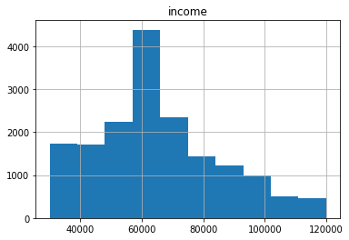

```python
hist = profile.hist(column = 'income')
```

```python
def cat_income(value):
    if value<40000:
        return "<40k"
    if value<60000:
        return "40k-60k"
    if value<80000:
        return '60k-80k'
    if value<100000:
        return "80k-100k"
    if value>40000:
        return '>100k'
```

```python
profile['income'] = profile['income'].apply(lambda x: cat_income(x))
income = pd.get_dummies(profile['income'])
```

```python
profile.drop(['income'], axis = 1, inplace = True)
profile = pd.concat([income,profile], axis = 1)
```

```python
profile.head()
```

|  | 40k-60k | 60k-80k | 80k-100k | <40k | >100k | 20-40 | 40-60 | 60-80 | <20 | >80 | ... | 2013 | 2014 | 2015 | 2016 | 2017 | 2018 | gender_F | gender_M | gender_O | gender_nan |
| --- | --- | --- | --- | --- | --- | --- | --- | --- | --- | --- | --- | --- | --- | --- | --- | --- | --- | --- | --- | --- | --- |
| 0 | 0 | 1 | 0 | 0 | 0 | 0 | 1 | 0 | 0 | 0 | ... | 0 | 0 | 0 | 0 | 1 | 0 | 0 | 0 | 0 | 1 |
| 1 | 0 | 0 | 0 | 0 | 1 | 0 | 1 | 0 | 0 | 0 | ... | 0 | 0 | 0 | 0 | 1 | 0 | 1 | 0 | 0 | 0 |
| 2 | 0 | 1 | 0 | 0 | 0 | 0 | 1 | 0 | 0 | 0 | ... | 0 | 0 | 0 | 0 | 0 | 1 | 0 | 0 | 0 | 1 |
| 3 | 0 | 0 | 0 | 0 | 1 | 0 | 0 | 1 | 0 | 0 | ... | 0 | 0 | 0 | 0 | 1 | 0 | 1 | 0 | 0 | 0 |
| 4 | 0 | 1 | 0 | 0 | 0 | 0 | 1 | 0 | 0 | 0 | ... | 0 | 0 | 0 | 0 | 1 | 0 | 0 | 0 | 0 | 1 |

5 rows × 21 columns

```python
per_person_offer_type = transcript.groupby(['person','event', 'offer']).count()
per_person_offer_count = pd.pivot_table(per_person_offer_type, values='time', index=['person'],
                       columns=['event', 'offer'], fill_value=0)
```

### Combining the transactions with the profile dataframe

```python
profile = profile.rename(columns={"id": "person"})
comb_profile_trans = pd.merge(profile, per_person_tran_count, on='person')
comb_profile_trans = pd.merge(comb_profile_trans,amount_spent_per_person,on='person')
comb_profile_trans.drop(['time'], axis= 1, inplace = True)
comb_profile_trans.set_index("person", inplace = True)
comb_profile_trans.head()
```

| person | 40k-60k | 60k-80k | 80k-100k | <40k | >100k | 20-40 | 40-60 | 60-80 | <20 | >80 | ... | 2018 | gender_F | gender_M | gender_O | gender_nan | offer completed | offer received | offer viewed | transaction | amount |
| --- | --- | --- | --- | --- | --- | --- | --- | --- | --- | --- | --- | --- | --- | --- | --- | --- | --- | --- | --- | --- | --- |
| 68be06ca386d4c31939f3a4f0e3dd783 | 0 | 1 | 0 | 0 | 0 | 0 | 1 | 0 | 0 | 0 | ... | 0 | 0 | 0 | 0 | 1 | 2 | 5 | 5 | 9 | 20.40 |
| 0610b486422d4921ae7d2bf64640c50b | 0 | 0 | 0 | 0 | 1 | 0 | 1 | 0 | 0 | 0 | ... | 0 | 1 | 0 | 0 | 0 | 1 | 2 | 0 | 3 | 77.01 |
| 38fe809add3b4fcf9315a9694bb96ff5 | 0 | 1 | 0 | 0 | 0 | 0 | 1 | 0 | 0 | 0 | ... | 1 | 0 | 0 | 0 | 1 | 0 | 2 | 2 | 6 | 14.30 |
| 78afa995795e4d85b5d9ceeca43f5fef | 0 | 0 | 0 | 0 | 1 | 0 | 0 | 1 | 0 | 0 | ... | 0 | 1 | 0 | 0 | 0 | 3 | 4 | 4 | 7 | 159.27 |
| a03223e636434f42ac4c3df47e8bac43 | 0 | 1 | 0 | 0 | 0 | 0 | 1 | 0 | 0 | 0 | ... | 0 | 0 | 0 | 0 | 1 | 0 | 5 | 3 | 3 | 4.65 |

5 rows × 25 columns

### offers details per person

```python
comb_prof_offers = pd.merge(profile, per_person_offer_count, on='person')
comb_prof_offers.set_index("person", inplace = True)
comb_prof_offers.head()
```

| person | 40k-60k | 60k-80k | 80k-100k | <40k | >100k | 20-40 | 40-60 | 60-80 | <20 | >80 | ... | (offer viewed, 1) | (offer viewed, 10) | (offer viewed, 2) | (offer viewed, 3) | (offer viewed, 4) | (offer viewed, 5) | (offer viewed, 6) | (offer viewed, 7) | (offer viewed, 8) | (offer viewed, 9) |
| --- | --- | --- | --- | --- | --- | --- | --- | --- | --- | --- | --- | --- | --- | --- | --- | --- | --- | --- | --- | --- | --- |
| 68be06ca386d4c31939f3a4f0e3dd783 | 0 | 1 | 0 | 0 | 0 | 0 | 1 | 0 | 0 | 0 | ... | 0 | 1 | 0 | 0 | 0 | 1 | 1 | 2 | 0 | 0 |
| 0610b486422d4921ae7d2bf64640c50b | 0 | 0 | 0 | 0 | 1 | 0 | 1 | 0 | 0 | 0 | ... | 0 | 0 | 0 | 0 | 0 | 0 | 0 | 0 | 0 | 0 |
| 38fe809add3b4fcf9315a9694bb96ff5 | 0 | 1 | 0 | 0 | 0 | 0 | 1 | 0 | 0 | 0 | ... | 0 | 0 | 0 | 0 | 1 | 0 | 0 | 0 | 1 | 0 |
| 78afa995795e4d85b5d9ceeca43f5fef | 0 | 0 | 0 | 0 | 1 | 0 | 0 | 1 | 0 | 0 | ... | 1 | 0 | 0 | 0 | 1 | 0 | 0 | 0 | 1 | 1 |
| a03223e636434f42ac4c3df47e8bac43 | 0 | 1 | 0 | 0 | 0 | 0 | 1 | 0 | 0 | 0 | ... | 0 | 0 | 0 | 1 | 0 | 2 | 0 | 0 | 0 | 0 |

5 rows × 40 columns

### Offers

```python
offers_completed = comb_profile_trans["offer completed"].reset_index()
per_person_offer_count =  pd.merge(per_person_offer_count,offers_completed , on='person')
per_person_offer_count.head()
```

|  | person | (offer received, 1) | (offer received, 10) | (offer received, 2) | (offer received, 3) | (offer received, 4) | (offer received, 5) | (offer received, 6) | (offer received, 7) | (offer received, 8) | ... | (offer viewed, 10) | (offer viewed, 2) | (offer viewed, 3) | (offer viewed, 4) | (offer viewed, 5) | (offer viewed, 6) | (offer viewed, 7) | (offer viewed, 8) | (offer viewed, 9) | offer completed |
| --- | --- | --- | --- | --- | --- | --- | --- | --- | --- | --- | --- | --- | --- | --- | --- | --- | --- | --- | --- | --- | --- |
| 0 | 0009655768c64bdeb2e877511632db8f | 0 | 1 | 0 | 1 | 0 | 0 | 0 | 1 | 1 | ... | 0 | 0 | 1 | 0 | 0 | 0 | 1 | 1 | 1 | 3 |
| 1 | 00116118485d4dfda04fdbaba9a87b5c | 0 | 0 | 0 | 0 | 0 | 0 | 0 | 0 | 0 | ... | 0 | 0 | 0 | 0 | 0 | 0 | 0 | 0 | 2 | 0 |
| 2 | 0011e0d4e6b944f998e987f904e8c1e5 | 0 | 0 | 0 | 1 | 1 | 1 | 1 | 0 | 1 | ... | 0 | 0 | 1 | 1 | 1 | 1 | 0 | 1 | 0 | 3 |
| 3 | 0020c2b971eb4e9188eac86d93036a77 | 1 | 0 | 1 | 0 | 0 | 0 | 0 | 2 | 1 | ... | 0 | 1 | 0 | 0 | 0 | 0 | 1 | 1 | 0 | 3 |
| 4 | 0020ccbbb6d84e358d3414a3ff76cffd | 0 | 0 | 0 | 0 | 1 | 0 | 1 | 0 | 1 | ... | 0 | 0 | 0 | 1 | 0 | 1 | 0 | 1 | 1 | 3 |

5 rows × 22 columns

```python
per_person_offer_count.columns = per_person_offer_count.columns.map("".join)
```

```python
per_person_offer_count.head()
```

|  | person | offer received1 | offer received10 | offer received2 | offer received3 | offer received4 | offer received5 | offer received6 | offer received7 | offer received8 | ... | offer viewed10 | offer viewed2 | offer viewed3 | offer viewed4 | offer viewed5 | offer viewed6 | offer viewed7 | offer viewed8 | offer viewed9 | offer completed |
| --- | --- | --- | --- | --- | --- | --- | --- | --- | --- | --- | --- | --- | --- | --- | --- | --- | --- | --- | --- | --- | --- |
| 0 | 0009655768c64bdeb2e877511632db8f | 0 | 1 | 0 | 1 | 0 | 0 | 0 | 1 | 1 | ... | 0 | 0 | 1 | 0 | 0 | 0 | 1 | 1 | 1 | 3 |
| 1 | 00116118485d4dfda04fdbaba9a87b5c | 0 | 0 | 0 | 0 | 0 | 0 | 0 | 0 | 0 | ... | 0 | 0 | 0 | 0 | 0 | 0 | 0 | 0 | 2 | 0 |
| 2 | 0011e0d4e6b944f998e987f904e8c1e5 | 0 | 0 | 0 | 1 | 1 | 1 | 1 | 0 | 1 | ... | 0 | 0 | 1 | 1 | 1 | 1 | 0 | 1 | 0 | 3 |
| 3 | 0020c2b971eb4e9188eac86d93036a77 | 1 | 0 | 1 | 0 | 0 | 0 | 0 | 2 | 1 | ... | 0 | 1 | 0 | 0 | 0 | 0 | 1 | 1 | 0 | 3 |
| 4 | 0020ccbbb6d84e358d3414a3ff76cffd | 0 | 0 | 0 | 0 | 1 | 0 | 1 | 0 | 1 | ... | 0 | 0 | 0 | 1 | 0 | 1 | 0 | 1 | 1 | 3 |

5 rows × 22 columns

## Data Visualization

```python
import seaborn as sns
import matplotlib.pyplot as plt
```

### Finding relation between user features and offers

- mat_1 = users x user_features
- mat_2 = users x offers
- mat_1.T . mat_2 = user_features x offers

```python
prof_offers = pd.merge(profile, per_person_offer_count, on='person')
```

```python
profile.shape, prof_offers.shape, per_person_offer_count.shape
```

```
((17000, 21), (16994, 42), (16994, 22))
```

```python
columns_list = ['person','offer received1', 'offer received10', 'offer received2',
       'offer received3', 'offer received4', 'offer received5',
       'offer received6', 'offer received7', 'offer received8',
       'offer received9']
```

```python
mat_11 = prof_offers[age.columns]
normalized_mat_11=(mat_11-mat_11.min())/(mat_11.max()-mat_11.min())
```

```python
mat_2 = prof_offers[columns_list].drop(['person'], axis =1)
normalized_mat_2 = (mat_2-mat_2.min())/(mat_2.max()-mat_2.min())
```

```python
income.columns
```

```
Index(['40k-60k', '60k-80k', '80k-100k', '<40k', '>100k'], dtype='object')
```

```python
gender.columns
```

```
Index(['gender_F', 'gender_M', 'gender_O', 'gender_nan'], dtype='object')
```

```python
mat_12 = prof_offers[gender.columns]
normalized_mat_12=(mat_12-mat_12.min())/(mat_12.max()-mat_12.min())
mat_21 = prof_offers[year_joined.columns]
normalized_mat_21=(mat_21-mat_21.min())/(mat_21.max()-mat_21.min())
mat_22 = prof_offers[income.columns]
normalized_mat_22=(mat_22-mat_22.min())/(mat_22.max()-mat_22.min())
```

```python
userfeatures_offers_recive = normalized_mat_11.T.dot(normalized_mat_2)
userfeatures12_offers_recive = normalized_mat_12.T.dot(normalized_mat_2)
userfeatures21_offers_recive = normalized_mat_21.T.dot(normalized_mat_2)
userfeatures22_offers_recive = normalized_mat_22.T.dot(normalized_mat_2)
```

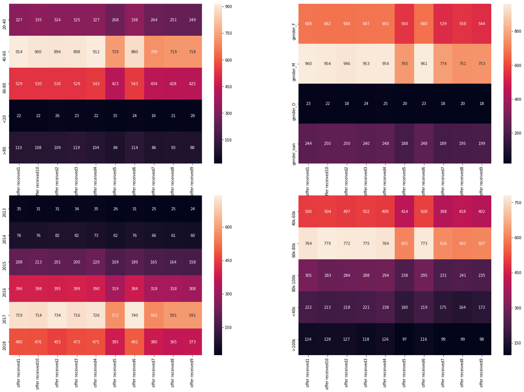

```python
fig, axes = plt.subplots(2, 2, figsize = (25, 17))
sns.heatmap(data = userfeatures_offers_recive, annot = True,  fmt = '.0f', ax = axes[0, 0])
sns.heatmap(data = userfeatures12_offers_recive, annot = True,  fmt = '.0f', ax = axes[0, 1])
sns.heatmap(data = userfeatures21_offers_recive, annot = True, fmt = '.0f', ax = axes[1, 0])
sns.heatmap(data = userfeatures22_offers_recive, annot = True, fmt = '.0f', ax = axes[1, 1]);
```

```python
for x in userfeatures_offers_recive:
    print(f'{x}')
    print(f'\tthe max value is for users age between {userfeatures_offers_recive[x].idxmax()} and it is {max(userfeatures_offers_recive[x])/sum(userfeatures_offers_recive[x]):2.2%} of users')
    print(f'\tthe min value is for users age between {userfeatures_offers_recive[x].idxmin()} and it is {min(userfeatures_offers_recive[x])/sum(userfeatures_offers_recive[x]):2.2%} of users')
    print(f'\tthe max value is for user with gender {userfeatures12_offers_recive[x].idxmax()} and it is {max(userfeatures12_offers_recive[x])/sum(userfeatures12_offers_recive[x]):2.2%} of users')
    print(f'\tthe min value is for user with gender {userfeatures12_offers_recive[x].idxmin()} and it is {min(userfeatures12_offers_recive[x])/sum(userfeatures12_offers_recive[x]):2.2%} of users')
    print(f'\tthe max value is for user joined in {userfeatures21_offers_recive[x].idxmax()} and it is {max(userfeatures21_offers_recive[x])/sum(userfeatures21_offers_recive[x]):2.2%} of users')
    print(f'\tthe min value is for user joined in {userfeatures21_offers_recive[x].idxmin()} and it is {min(userfeatures21_offers_recive[x])/sum(userfeatures21_offers_recive[x]):2.2%} of users')
    print(f'\tthe max value is for users with income {userfeatures22_offers_recive[x].idxmax()} and it is {max(userfeatures22_offers_recive[x])/sum(userfeatures22_offers_recive[x]):2.2%} of users')
    print(f'\tthe min value is for users with income {userfeatures22_offers_recive[x].idxmin()} and it is {min(userfeatures22_offers_recive[x])/sum(userfeatures22_offers_recive[x]):2.2%} of users')
```

```
offer received1
	the max value is for users age between 40-60 and it is 48.06% of users
	the min value is for users age between <20 and it is 1.13% of users
	the max value is for user with gender gender_M and it is 50.14% of users
	the min value is for user with gender gender_O and it is 1.21% of users
	the max value is for user joined in 2017 and it is 37.56% of users
	the min value is for user joined in 2013 and it is 1.83% of users
	the max value is for users with income 60k-80k and it is 39.92% of users
	the min value is for users with income >100k and it is 6.45% of users
offer received10
	the max value is for users age between 40-60 and it is 47.45% of users
	the min value is for users age between <20 and it is 1.16% of users
	the max value is for user with gender gender_M and it is 49.99% of users
	the min value is for user with gender gender_O and it is 1.15% of users
	the max value is for user joined in 2017 and it is 37.43% of users
	the min value is for user joined in 2013 and it is 1.61% of users
	the max value is for users with income 60k-80k and it is 40.83% of users
	the min value is for users with income >100k and it is 6.73% of users
offer received2
	the max value is for users age between 40-60 and it is 47.48% of users
	the min value is for users age between <20 and it is 1.38% of users
	the max value is for user with gender gender_M and it is 49.84% of users
	the min value is for user with gender gender_O and it is 0.95% of users
	the max value is for user joined in 2017 and it is 38.68% of users
	the min value is for user joined in 2013 and it is 1.65% of users
	the max value is for users with income 60k-80k and it is 40.70% of users
	the min value is for users with income >100k and it is 6.68% of users
offer received3
	the max value is for users age between 40-60 and it is 47.41% of users
	the min value is for users age between <20 and it is 1.23% of users
	the max value is for user with gender gender_M and it is 50.05% of users
	the min value is for user with gender gender_O and it is 1.26% of users
	the max value is for user joined in 2017 and it is 37.60% of users
	the min value is for user joined in 2013 and it is 1.76% of users
	the max value is for users with income 60k-80k and it is 40.70% of users
	the min value is for users with income >100k and it is 6.17% of users
offer received4
	the max value is for users age between 40-60 and it is 47.75% of users
	the min value is for users age between <20 and it is 1.18% of users
	the max value is for user with gender gender_M and it is 49.72% of users
```

[output cut: 35 more lines]

```
	the max value is for user with gender gender_M and it is 49.29% of users
	the min value is for user with gender gender_O and it is 1.30% of users
	the max value is for user joined in 2017 and it is 38.82% of users
	the min value is for user joined in 2013 and it is 1.61% of users
	the max value is for users with income 60k-80k and it is 39.51% of users
	the min value is for users with income >100k and it is 6.51% of users
offer received9
	the max value is for users age between 40-60 and it is 47.85% of users
	the min value is for users age between <20 and it is 1.35% of users
	the max value is for user with gender gender_M and it is 49.76% of users
	the min value is for user with gender gender_O and it is 1.16% of users
	the max value is for user joined in 2017 and it is 39.04% of users
	the min value is for user joined in 2013 and it is 1.58% of users
	the max value is for users with income 60k-80k and it is 40.11% of users
	the min value is for users with income >100k and it is 6.46% of users
```

## Summary From the heatmap:

- Age:
  - people with age between 40-60 are recieving offers more than other ages.
  - people with age between 40-60 are recieving offers 1,2,3,4,6,10 more than other offers.
  - people under 20 year are the least people to recieve offers.
- gender:
  - Male are most likely recieved offers 1,2,3,4,6,10 more than other offers.
  - females are most likely recieved offers 1,2,3,4,6,10 more than other offers.
  - People with gender other are not likely to recive offers.
  - people who didn't specify their gender is most likely recieved offers 1,2,3,4,6,10 more than other offers.
  - males are recieving offers more than all other genders.
- Joining date:
  - people joined in 2017 are most likely to recive offers 1,2,3,4,10 more than other offers.
  - people joined in 2017 are recieving offers more than all other joining dates.
  - people joined in 2013 and 2014 are the lowest in reciving offers.
- income:
  - people with income between 60K and 80K are most likely recieve offers than other income levels followed by the income level of 40k to 60k.
  - people with income between 60K and 80K recives offers 1,2,3,4,6,10 other than other offers.

```python
columns_list = ['offer viewed1', 'offer viewed10',
       'offer viewed2', 'offer viewed3', 'offer viewed4', 'offer viewed5',
       'offer viewed6', 'offer viewed7', 'offer viewed8', 'offer viewed9','offer completed']

mat_2 = prof_offers[columns_list]
normalized_mat_2 = (mat_2-mat_2.min())/(mat_2.max()-mat_2.min())
```

```python
userfeatures11_offers_view = normalized_mat_11.T.dot(normalized_mat_2)
userfeatures12_offers_view = normalized_mat_12.T.dot(normalized_mat_2)
userfeatures21_offers_view = normalized_mat_21.T.dot(normalized_mat_2)
userfeatures22_offers_view = normalized_mat_22.T.dot(normalized_mat_2)
```

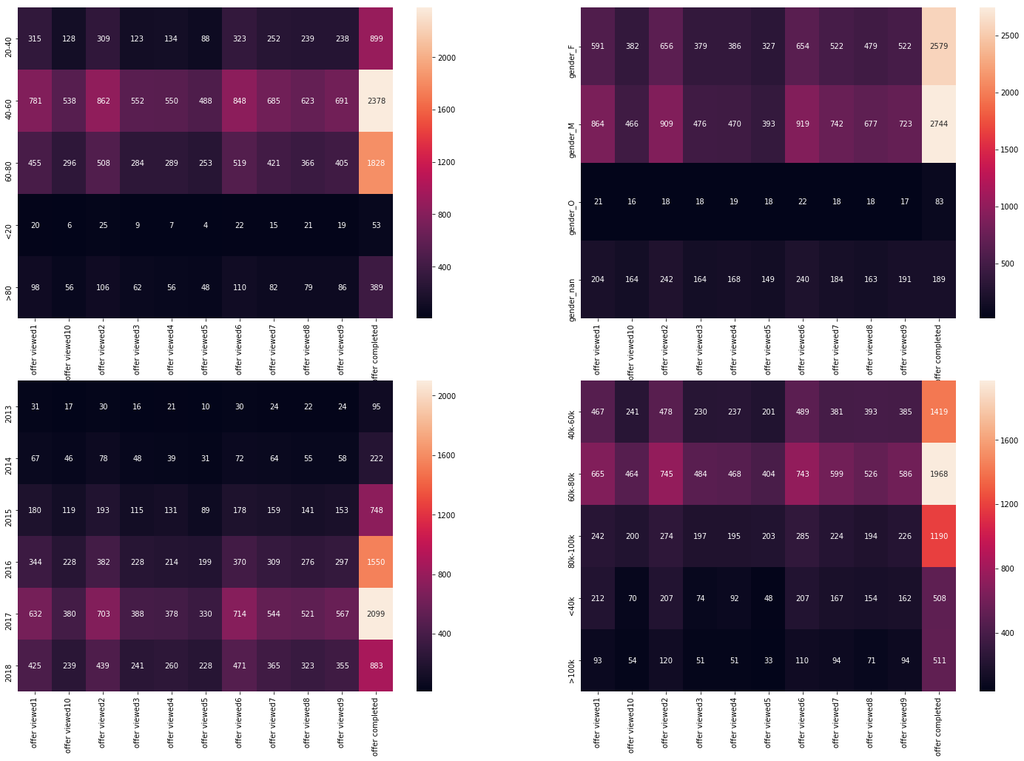

```python
fig, axes = plt.subplots(2, 2, figsize = (25, 17))
sns.heatmap(data = userfeatures11_offers_view, annot = True,  fmt = '.0f', ax = axes[0, 0])
sns.heatmap(data = userfeatures12_offers_view, annot = True,  fmt = '.0f', ax = axes[0, 1])
sns.heatmap(data = userfeatures21_offers_view, annot = True, fmt = '.0f', ax = axes[1, 0])
sns.heatmap(data = userfeatures22_offers_view, annot = True, fmt = '.0f', ax = axes[1, 1]);
```

```python
for x in userfeatures11_offers_view:
    print(f'{x}')
    print(f'\tthe max value is for users age between {userfeatures11_offers_view[x].idxmax()} and it is {max(userfeatures11_offers_view[x])/sum(userfeatures11_offers_view[x]):2.2%} of users')
    print(f'\tthe min value is for users age between {userfeatures11_offers_view[x].idxmin()} and it is {min(userfeatures11_offers_view[x])/sum(userfeatures11_offers_view[x]):2.2%} of users')
    print(f'\tthe max value is for user with gender {userfeatures12_offers_view[x].idxmax()} and it is {max(userfeatures12_offers_view[x])/sum(userfeatures12_offers_view[x]):2.2%} of users')
    print(f'\tthe min value is for user with gender {userfeatures12_offers_view[x].idxmin()} and it is {min(userfeatures12_offers_view[x])/sum(userfeatures12_offers_view[x]):2.2%} of users')
    print(f'\tthe max value is for user joined in {userfeatures21_offers_view[x].idxmax()} and it is {max(userfeatures21_offers_view[x])/sum(userfeatures21_offers_view[x]):2.2%} of users')
    print(f'\tthe min value is for user joined in {userfeatures21_offers_view[x].idxmin()} and it is {min(userfeatures21_offers_view[x])/sum(userfeatures21_offers_view[x]):2.2%} of users')
    print(f'\tthe max value is for users with income {userfeatures22_offers_view[x].idxmax()} and it is {max(userfeatures22_offers_view[x])/sum(userfeatures22_offers_view[x]):2.2%} of users')
    print(f'\tthe min value is for users with income {userfeatures22_offers_view[x].idxmin()} and it is {min(userfeatures22_offers_view[x])/sum(userfeatures22_offers_view[x]):2.2%} of users')
```

```
offer viewed1
	the max value is for users age between 40-60 and it is 46.81% of users
	the min value is for users age between <20 and it is 1.23% of users
	the max value is for user with gender gender_M and it is 51.43% of users
	the min value is for user with gender gender_O and it is 1.24% of users
	the max value is for user joined in 2017 and it is 37.64% of users
	the min value is for user joined in 2013 and it is 1.86% of users
	the max value is for users with income 60k-80k and it is 39.61% of users
	the min value is for users with income >100k and it is 5.54% of users
offer viewed10
	the max value is for users age between 40-60 and it is 52.53% of users
	the min value is for users age between <20 and it is 0.63% of users
	the max value is for user with gender gender_M and it is 45.31% of users
	the min value is for user with gender gender_O and it is 1.58% of users
	the max value is for user joined in 2017 and it is 36.89% of users
	the min value is for user joined in 2013 and it is 1.68% of users
	the max value is for users with income 60k-80k and it is 45.07% of users
	the min value is for users with income >100k and it is 5.20% of users
offer viewed2
	the max value is for users age between 40-60 and it is 47.63% of users
	the min value is for users age between <20 and it is 1.38% of users
	the max value is for user with gender gender_M and it is 49.81% of users
	the min value is for user with gender gender_O and it is 0.97% of users
	the max value is for user joined in 2017 and it is 38.53% of users
	the min value is for user joined in 2013 and it is 1.66% of users
	the max value is for users with income 60k-80k and it is 40.85% of users
	the min value is for users with income >100k and it is 6.58% of users
offer viewed3
	the max value is for users age between 40-60 and it is 53.58% of users
	the min value is for users age between <20 and it is 0.87% of users
	the max value is for user with gender gender_M and it is 45.90% of users
	the min value is for user with gender gender_O and it is 1.69% of users
	the max value is for user joined in 2017 and it is 37.45% of users
	the min value is for user joined in 2013 and it is 1.59% of users
	the max value is for users with income 60k-80k and it is 46.72% of users
	the min value is for users with income >100k and it is 4.90% of users
offer viewed4
	the max value is for users age between 40-60 and it is 53.12% of users
	the min value is for users age between <20 and it is 0.70% of users
	the max value is for user with gender gender_M and it is 45.05% of users
```

[output cut: 44 more lines]

```
	the max value is for user with gender gender_M and it is 49.74% of users
	the min value is for user with gender gender_O and it is 1.17% of users
	the max value is for user joined in 2017 and it is 39.01% of users
	the min value is for user joined in 2013 and it is 1.62% of users
	the max value is for users with income 60k-80k and it is 40.31% of users
	the min value is for users with income >100k and it is 6.44% of users
offer completed
	the max value is for users age between 40-60 and it is 42.86% of users
	the min value is for users age between <20 and it is 0.96% of users
	the max value is for user with gender gender_M and it is 49.04% of users
	the min value is for user with gender gender_O and it is 1.49% of users
	the max value is for user joined in 2017 and it is 37.51% of users
	the min value is for user joined in 2013 and it is 1.69% of users
	the max value is for users with income 60k-80k and it is 35.16% of users
	the min value is for users with income <40k and it is 9.08% of users
```

## Summary from the privious heatmap

- Offers viewed:
  - most men opened offers 1,2,6 more than other offers.
  - people with other or nan gender are the least in viewing the offers.
  - people with age less than 20 is the least people to view offers.
  - people with age between 40-60 are the most people to view offers.
  - people joined in 2017 are the most people to view offers.
  - people joined in 2013 are the least people to view offers.
  - people with income netween 60-80K are most people to view offers.
  - people with income more than 100k are least pople to view offers.
- offers completed:
  - Males comes first in completing the offers then Females.
  - people joined in 2017 are most likely to complete the offers.
  - people with age less than 20 is the least people to complete offers.
  - people with age between 40-60 are the most people to complete offers.
  - people joined in 2013 are the least people to complete offers.
  - people with income netween 60-80K are most people to complete offers.
  - people with income less than 40K are least pople to complete offers.